# Developing Data Products Week 4 Project

Pitch of my shiny app

Sarah Lott

2023-04-20

# Task

**Your Reproducible Pitch Presentation**

OK, you’ve made your shiny app, now it’s time to make your pitch. You get 5 slides (inclusive of the title slide) to pitch a your app. You’re going to create a web page using Slidify or Rstudio Presenter with an html5 slide deck.

Here’s what you need

- 5 slides to pitch our idea done in Slidify or Rstudio Presenter
- Your presentation pushed to github or Rpubs
- A link to your github or Rpubs presentation pasted into the provided text box

Your presentation must satisfy the following

- It must be done in Slidify or Rstudio Presenter
- It must be 5 pages
- It must be hosted on github or Rpubs
- It must contained some embedded R code that gets run when slidifying the document

# Appearance of the app

This is how the app looks like:

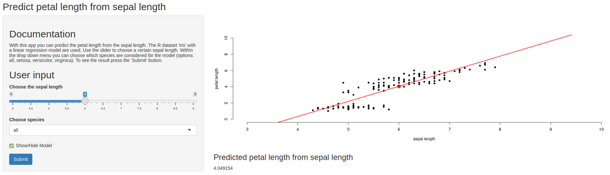

see https://sarlo.shinyapps.io/developingdataproductsweek4/

# Explanation

The app can be used to predict the petal length from the sepal length. The basis is the R-dataset “iris”. The app fits a linear regression model to the given data. You can select which species shall be considered for the fitting.

# Example

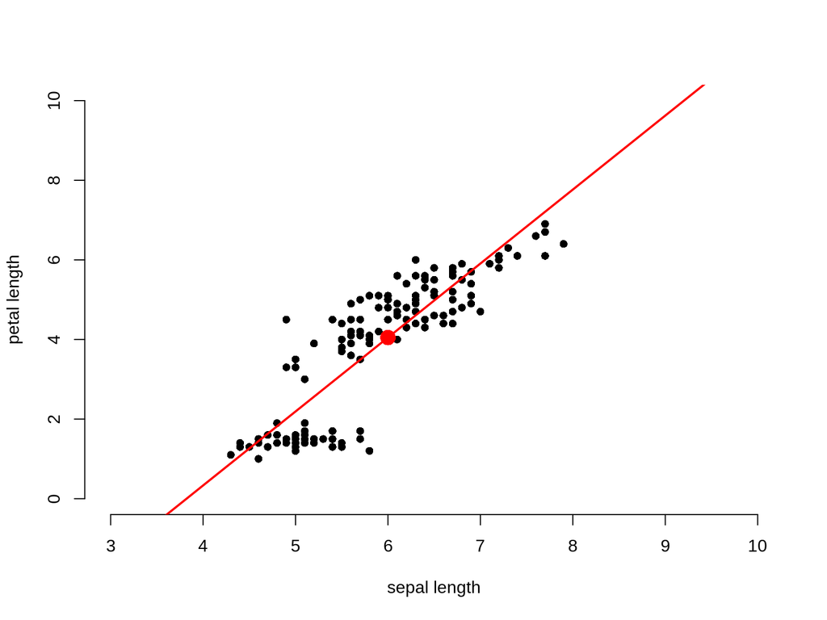

```r
model <- lm(Petal.Length ~ Sepal.Length, data = iris)
modelpred <- predict(model, newdata = data.frame(Sepal.Length = 6))
plot(iris$Sepal.Length, iris$Petal.Length, xlab = "sepal length",
     ylab = "petal length", bty = "n", pch = 16,
     xlim = c(3, 10), ylim = c(0, 10))
abline(model, col = "red", lwd = 2)
points(6, modelpred, col = "red", pch = 16, cex = 2)
```